# DS-GA 1003: Machine Learning and Computational Statistics

## Homework 3: SVM and Sentiment Analysis

### 2. Calculating Subgradients

2.1 [Subgradients for pointwise maximum of functions] Suppose $f_{1},\ldots,f_{m}:\mathbf R^{d}\to\mathbf R$ are convex functions, and $$f(x)=\max_{i=1,\ldots,,m}f_{i}(x).$$ Let $k$ be any index for which $f_{k}(x)=f(x)$, and choose $g\in\partial f_{k}(x)$.[We are using the fact that a convex function on $\mathbf R^{d}$ has a non-empty subdifferential at all points.] Show that Formula $g\in\partial f(x)$

> **ANSWER:**

> Let $k$ be any index for which $f_k(x)=f(x)$, and choose $g\in \partial f_k(x)$.

> $$f(z)\geq f_k(z)\geq f_k(x)+g^T(z-x)=f(x)+g^T(z-x)$$

> So for $g\in \partial f_k(x)$, $g\in \partial f(x)$.

> For the subdifferiential $\partial f(x)$, we have $$\partial f(x)=\mathbf{Co}\cup\{\nabla f_i(x)|f_i(x)=f(x)\}$$

2.2 [Subgradient of hinge loss for linear prediction] Give a subgradient of $$J(w)=\max\left\{ 0,1-yw^{T}x\right\}$$.

> **ANSWER:**

> $\partial f(x)$=max{0, $-y_nx_n$}

### 3. Perceptron

In this problem we will see why this loss function has this name.

3.1. Show that if $\{x | w^T x=0\}$ is a separating hyperplane for a training set $\mathcal D = ((x_1, y_1), . . . ,(x_n, y_n))$, then the average perceptron loss on D is 0.

> **ANSWER:**

> $\begin{array}{lll} \frac{\ell(D)}{n}&=&\frac{1}{n}\sum_{i=1}^n max(0,-\hat{y_i}y_i)\\ &=&\frac{1}{n}\sum_{i=1}^n max(0,-w_ix_iy_i)\\ \end{array}$

> $\{x|w^Tx=0\}$ seperates the training set,

> $$\forall i, w_ix_iy_i>0, \frac{\ell(D)}{n}=0$$

3.2. Let $\mathcal H$ be the linear hypothesis space consisting of functions $x \mapsto w^T x$. Consider running SGD to minimize the empirical risk with the perceptron loss. We’ll use the version of SGD in which we cycle through the data points in each epoch. Show that if we use a fixed step size 1 and we terminate when our training loss is 0, then we are exactly doing the Perceptron algorithm.

> **ANSWER:**

> The update rule for w in Stochastic Subgradient Descend is,

> $$w_{t} = w_{t-1}-\partial_w[max(0,-w_{t-1}^Tx_{t-1}y_{t-1})] $$$$w_{t}=\begin{cases} w_{t-1}&-w_{t-1}^Tx_{t-1}y_{t-1}<0\\ w_{t-1}+y_{t-1}x_{t-1}&-w_{t-1}^Tx_{t-1}y_{t-1}\geq0\\ \end{cases}$$

> And terminates at training loss is 0 means $$\forall i, -w_{t-1}^Tx_{t-1}y_{t-1}<0$$

> Which is exactly the perceptron algorithm is.

3.3. Suppose the perceptron algorithm returns $w$. Show that $w$ is a linear combination of the input points. That is, we can write $w =\sum_{i=1}^n \alpha_ix_i$ for some $\alpha_1,..., \alpha_n \in \mathbf R$. The $x_i$ for which $\alpha_i\neq0$ are called support vectors. Give a characterization of points that are support vectors and not support vectors with regard to what happens with them during the algorithm.

> **ANSWER**

> The support vectors in the perceptron algorithm are those misclassified during the algorithm.

### 4. The Data

Load all the data and randomly split it into 1500 training examples and 500 test examples.

```python
#Prep
import os
import numpy as np
import pandas as pd
import random
import collections
import time
from datetime import datetime
import matplotlib.pyplot as plt
from __future__ import division,print_function
%matplotlib inline
```

```python
def timing(f):
    def wrap(*args):
        time1 = time.time()
        ret = f(*args)
        time2 = time.time()
        print('%s function took %0.3f ms' % (f.func_name, (time2-time1)*1000.0))
        return ret
    return wrap
```

```python
def folder_list(path,label):
    '''
    Take path to a directory, apply the label the contained documents,
    and return the list of documents
    PARAMETER PATH IS THE PATH OF YOUR LOCAL FOLDER
    Label is positive or negative
    '''
    filelist = os.listdir(path)
    review = []
    for infile in filelist:
        myfile = os.path.join(path,infile)
        r = read_data(myfile)
        r.append(label)
        r.append(infile) #add file id for later reference
        review.append(r)
    return review

def read_data(file_path):
    '''
    Read each file into a list of strings.
    Example:
    ["it's", 'a', 'curious', 'thing', "i've", 'found', 'that', 'when', 'willis', 'is', 'not', 'called', 'on',
    ...'to', 'carry', 'the', 'whole', 'movie', "he's", 'much', 'better', 'and', 'so', 'is', 'the', 'movie']
    '''
    f = open(file_path)
    lines = f.read().split(' ')
    symbols = '${}()[].,:;+-*/&|<>=~"_`\' '
    words = map(lambda Element: Element.translate(None, symbols).strip(), lines)
    words = filter(None, words)
    return words

def train_test_split(data,pivot_index):
    '''
    split list of documents into training and test sets
    '''
    random.seed(1)
    random.shuffle(data)
    train = data[:pivot_index]
    test = data[pivot_index:]
    assert len(train)==pivot_index, "Training set is not proper length"
    return train,test

def load_data():
    '''
    pos_path is where you save positive review data.
    neg_path is where you save negative review data.
    '''
    home_dir = os.getcwd()
    pos_path = os.path.join(home_dir,"data/pos")
    neg_path = os.path.join(home_dir,"data/neg")

    pos_review = folder_list(pos_path,1)
    neg_review = folder_list(neg_path,-1)

    review = pos_review + neg_review
    return train_test_split(review,1500)

train,test = load_data()
```

### 5. Sparse Representations

5.1. Write a function that converts an example (e.g. a list of words) into a sparse bag-of-words representation.

```python
def lst2bag(lst):
    bags = map(lambda x:collections.Counter(x[:-2]),lst)
    labels = map(lambda x:x[-2],lst)
    ids = map(lambda x:x[-1],lst)
    return bags, labels, ids
```

### 6. Support Vector Machine via Pegasos

6.1. Compute a subgradient for the “stochastic” SVM objective, which assumes a single training point. Show that if your step size rule is $\eta_t=\frac{1}{\lambda_t}$, then the corresponding SGD update is the same as given in the pseudocode.

> **ANSWER**

> The stochastic SVM objective function is $$J(w)=\min\limits_{w}\frac{\lambda}{2}\|w\|^2+\frac{1}{m}\sum_{i=1}^{m}(1-y_iw^Tx_i)_+$$

> $$J_i(w)=\begin{cases} \frac{\lambda}{2m}\|w\|^2+1-y_iw^Tx_i & \text{if $y_iw^Tx_i<1$,}\\ \frac{\lambda}{2m}\|w\|^2 & \text{otherwise.} \end{cases}$$$$\nabla_w J_i(w)=\frac{\lambda w}{m}-\mathbb 1(y_iw^Tx_i<1)y_ix_i$$$$w_t = w_{t-1}-\eta_t\nabla_w J_i(w_{t-1})=(1-\eta_tw_{t-1})w_{t-1}-\mathbb 1(y_iw^Tx_i<1)\eta_iy_ix_i$$

6.2. Implement the Pegasos algorithm to run on a sparse data representation. The output should be a sparse weight vector w. Note that our Pegasos algorithm starts at w = 0. In a sparse representation, this corresponds to an empty dictionary. With this problem, you will need to take some care to code things efficiently. In particular, be aware that making copies of the weight dictionary can slow down your code significantly. If you want to make a copy of your weights (e.g. for checking for convergence), make sure you don’t do this more than once per epoch.

```python
def dotProduct(d1, d2):
    """
    @param dict d1: a feature vector represented by a mapping from a feature (string) to a weight (float).
    @param dict d2: same as d1
    @return float: the dot product between d1 and d2
    """
    if len(d1) < len(d2):
        return dotProduct(d2, d1)
    else:
        return sum(d1.get(f, 0) * v for f, v in d2.items())

def increment(d1, scale, d2):
    """
    Implements d1 += scale * d2 for sparse vectors.
    @param dict d1: the feature vector which is mutated.
    @param float scale
    @param dict d2: a feature vector.

    NOTE: This function does not return anything, but rather
    increments d1 in place. We do this because it is much faster to
    change elements of d1 in place than to build a new dictionary and
    return it.
    """
    for f, v in d2.items():
        if f in d1:
            d1[f] = d1.get(f, 0) + v * scale
    return d1
```

```python
@timing

def pegasos(X,y,W_init,Lambda,max_epoch):
    m = len(X)
    t = 0
    epoch=0
    W = w_init.copy()
    while epoch<max_epoch:
        for j in range(m):
            t+=1
            step = 1/(t*Lambda)
            for feature,value in W.items():
                W[feature] = value*(1-step*Lambda)
            if( y[j]*dotProduct(W,X[j]) )<1:
                increment(W,step*y[j],X[j])
        epoch+=1
        print(epoch)
    return W
```

```python
def initW(bags):
    #     Get full dictionary
    c = collections.Counter()
    for review in bags:
        c.update(review)
    w = {}
    for key,value in c.items():
        w[key] = 0
    return w
```

```python
bag_train,label_train,ids_train = lst2bag(train)
bag_test,label_test,ids_test = lst2bag(test)
w_init = initW(bag_train)
```

```python
w = pegasos(bag_train,label_train,w_init,0.1,1)
```

```
1
pegasos function took 91160.556 ms
```

6.3. Implement the Pegasos algorithm with change in update.

```python
@timing
def implemented_pegasos(X,y,W_init,Lambda,max_epoch):
    m = len(X)
    t=s=1
    epoch=0
    W = W_init.copy()
    while epoch<max_epoch:
        for j in range(m):
            t+=1
            step = 1/(t*Lambda)
            s=(1-step*Lambda)*s
            if( y[j]*dotProduct(W,X[j]) )<1:
                increment(W,step*y[j]/s,X[j])
        epoch+=1
    #Scale w:
    w={}
    for f,v in W.items():
        w[f]=v*s
    return w
```

```python
w_imp = implemented_pegasos(bag_train,label_train,w_init,1,50)
```

```
implemented_pegasos function took 11591.152 ms
```

6.4. Run both implementations of Pegasos to train an SVM on the training data (using the bag-of-words feature representation described above). Make sure your implementations are correct by verifying that the two approaches give essentially the same result. Report on the time taken to run each approach.

6.5. Write a function that takes a sparse weight vector w and a collection of $(x,y)$ pairs, and returns the percent error when predicting y using $sign(w^Tx)$. In other words, the function reports the 0-1 loss of the linear predictor $x\mapsto w^Tx.$

```python
def get_err(X,y,w):
    num = 0
    for i in range(len(X)):
        if dotProduct(w,X[i])*y[i]<0:
            num += 1
    return num/len(X)
```

```python
get_err(bag_test,label_test,w_imp)
```

```
0.146
```

6.6. Using the bag-of-words feature representation described above, search for the regularization parameter that gives the minimal percent error on your test set. A good search strategy is to start with a set of lambdas spanning a broad range of orders of magnitude. Then, continue to zoom in until you’re convinced that additional search will not significantly improve your test performance. Once you have a sense of the general range of regularization parameters that give good results, you do not have to search over orders of magnitude every time you change something (such as adding new feature).

```python
def lambda_search(lambdas,X,y):
    loss_history = []
    f = True
    loss_opt=0
    for Lambda in lambdas:
        w_search = implemented_pegasos(X,y,w_init,Lambda,50)
        loss = get_err(bag_test,label_test,w_search)
        loss_history.append(loss)
        print("Lambda is {0}, err is {1}.".format(Lambda,loss))
        if f or loss<loss_opt:
            f=False
            loss_opt = loss
            w_opt = w_search
            lambda_opt = Lambda
    return lambda_opt,w_opt,loss_opt,loss_history
```

```python
Lambdas=map(lambda x:10**x,np.linspace(2,-4,10))
lambda_opt,w_opt, loss_opt, loss_history = lambda_search(Lambdas,bag_train,label_train)
print('Best lambda = {0}'.format(lambda_opt))
```

```
implemented_pegasos function took 15003.746 ms
Lambda is 100.0, err is 0.146.
implemented_pegasos function took 14886.406 ms
Lambda is 21.5443469003, err is 0.144.
implemented_pegasos function took 14964.526 ms
Lambda is 4.64158883361, err is 0.148.
implemented_pegasos function took 14910.793 ms
Lambda is 1.0, err is 0.146.
implemented_pegasos function took 15189.747 ms
Lambda is 0.215443469003, err is 0.152.
implemented_pegasos function took 14853.362 ms
Lambda is 0.0464158883361, err is 0.152.
implemented_pegasos function took 14869.276 ms
Lambda is 0.01, err is 0.152.
implemented_pegasos function took 14781.000 ms
Lambda is 0.00215443469003, err is 0.152.
implemented_pegasos function took 14835.016 ms
Lambda is 0.000464158883361, err is 0.152.
implemented_pegasos function took 14777.935 ms
Lambda is 0.0001, err is 0.152.
Best lambda = 21.5443469003
```

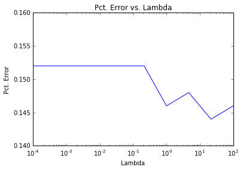

```python
plt.plot(Lambdas,loss_history)
plt.ylim(0.14,0.16)
plt.xlabel('Lambda')
plt.ylabel('Pct. Error')
plt.xscale('log')
plt.title('Pct. Error vs. Lambda')
plt.show()
```

```python
Lambdas=np.linspace(1,0.001,10)
lambda_opt,w_opt, loss_opt, loss_history = lambda_search(Lambdas,bag_train,label_train)
print('Best lambda = {0}'.format(lambda_opt))
```

```
implemented_pegasos function took 15045.886 ms
Lambda is 1.0, err is 0.146.
implemented_pegasos function took 14787.031 ms
Lambda is 0.889, err is 0.152.
implemented_pegasos function took 15012.624 ms
Lambda is 0.778, err is 0.152.
implemented_pegasos function took 14848.043 ms
Lambda is 0.667, err is 0.152.
implemented_pegasos function took 14910.439 ms
Lambda is 0.556, err is 0.152.
implemented_pegasos function took 14968.291 ms
Lambda is 0.445, err is 0.152.
implemented_pegasos function took 554500.128 ms
Lambda is 0.334, err is 0.152.
implemented_pegasos function took 16446.209 ms
Lambda is 0.223, err is 0.152.
implemented_pegasos function took 16492.498 ms
Lambda is 0.112, err is 0.152.
implemented_pegasos function took 15603.160 ms
Lambda is 0.001, err is 0.152.
Best lambda = 1.0
```

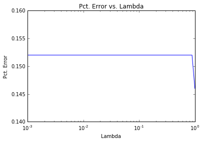

```python
plt.plot(Lambdas,loss_history)
plt.ylim(0.14,0.16)
plt.xlabel('Lambda')
plt.ylabel('Pct. Error')
plt.xscale('log')
plt.title('Pct. Error vs. Lambda')
plt.show()
```

6.7. [Optional] Recall that the “score” is the value of the prediction $f(x)=w^Tx$. We like to think that the magnitude of the score represents the confidence of the prediction. This is something we can directly verify or refute. Break the predictions into groups based on the score (you can play with the size of the groups to get a result you think is informative). For each group, examine the percentage error. You can make a table or graph. Summarize the results. Is there a correlation between higher magnitude scores and accuracy?

```python
get_err(bag_test,label_test,w_opt)
```

```
0.146
```

```python
scores = []
for bag in bag_test:
    score = dotProduct(w_opt, bag)
    scores.append(score)

score_df=pd.DataFrame(zip(scores,label_test))
score_df.columns=('score','label')
score_df['prediction']=np.sign(score_df['score'])
score_df['err']= map(lambda x:int(x),score_df['label']!=score_df['prediction'])
groups = score_df.groupby(pd.cut(score_df.score,10))
groups.sum()
```

| score | score | label | prediction | err |
| --- | --- | --- | --- | --- |
| (-0.13, -0.0942] | -0.639351 | -6 | -6 | 0 |
| (-0.0942, -0.0583] | -1.200837 | -17 | -17 | 0 |
| (-0.0583, -0.0225] | -3.739737 | -86 | -98 | 6 |
| (-0.0225, 0.0133] | -0.944961 | -52 | -58 | 51 |
| (0.0133, 0.0491] | 3.668644 | 97 | 129 | 16 |
| (0.0491, 0.0849] | 2.900281 | 46 | 46 | 0 |
| (0.0849, 0.121] | 1.012267 | 10 | 10 | 0 |
| (0.121, 0.157] | 0.141251 | 1 | 1 | 0 |
| (0.157, 0.192] | NaN | NaN | NaN | NaN |
| (0.192, 0.228] | 0.228237 | 1 | 1 | 0 |

> **ANSWER**

> Scores $\in [-0.0583,0.0491]$ has most percentage error. So the larger the magitude of score, the more accurate the prediction is.

6.8. [Optional] Our objective is not differentiable when $w^Tx_i=0$. Investigate how often and when we have $w^Tx_i=0$. Describe your findings. If we didn’t know about subgradients, one might suggest just skipping the update when $w^Tx_i=0$. Does this seem reasonable?

### 7. Error Analysis

Choose some examples that the model got wrong. List the features that contributed most heavily to the descision (e.g. rank them by $\|w_ix_i\|$), along with $x_i$, $w_i$, $xw_i$. Do you understand why the model was incorrect? Can you think of a new feature that might be able to fix the issue? Include a short analysis for at least 2 incorrect examples

> **ANSWER**

> The first misclassified test file is cv580_14064.txt. It's a really strange review, the author holds an almost neutral attitude and even don't recommend at the last. The word "this" and "movie" classified as negative, which will help if we remove them.

> The second file contains many "and" and "the". We may want to remove these stopwords to improve it.

```python
def example_analysis(i):
    print("File",ids_test[i])
    print("True sentiment: ",label_test[i],
          ".  Predicted sentiment: ",wrong.loc[i,'prediction'],
          ". Score: ", wrong.loc[i,"score"])
    f = open(wrong.loc[i,'name'])
    lines = f.read()
    print(lines)
    bow = bag_test[i]
    feature_dict = {}
    for key in bow:
        w=w_opt[key] if (key in w_opt.keys()) else np.nan
        x=bow[key]
        feature_dict[key]={'abs_xw':abs(x*w),'x':x,'w':w,'xw':x*w}
    feature_df = pd.DataFrame.from_dict(feature_dict,'index')
    print(feature_df.sort('abs_xw',ascending=False)[:10],"\n")
```

```python
scores = []
for bag in bag_test:
    score = dotProduct(w_opt, bag)
    scores.append(score)

score_df=pd.DataFrame(zip(scores,label_test))
score_df.columns=('score','label')
score_df['prediction']=np.sign(score_df['score'])
score_df['err']= map(lambda x:int(x),score_df['label']!=score_df['prediction'])
wrong = score_df[score_df.err==1]
wrong_name = []
for w in wrong.iterrows():
    if int(w[1].label)==1:
        name = "data/pos/"
    else:
        name = "data/neg/"
    name+=ids_test[w[0]]
    wrong_name.append(name)
wrong['name']=wrong_name
for i in wrong.index[:5]:
    example_analysis(i)
```

```
File cv580_14064.txt
True sentiment:  1 .  Predicted sentiment:  -1.0 . Score:  -0.0267329768936
this movie was one of the first american films done by director paul verhoeven .
he has done films since then such as basic instict and starship troopers .
all of his movies have one main thing in common- they don't skimp on the violence .
in a verhoeven movie a guy doesn't get shot once in the chest- he gets shot many times all over the body .
robocop takes place in detroit in the future .
things are pretty bleak .
the company ocp rules the city with an iron fist and is moving in on running the police force .
peter weller plays a cop who goes on a mission with his partner , nancy allen .
peter weller goes in an empty room alone and gets killed .
meanwhile ocp has a failed demonstration of a ed-209 model robot crime fighter .
someone comes up with the idea of having a cyborg robocop so they use any parts worth scalvaging from peter weller and make him into the robocop the movie is titled after .
the plot of this movie generally runs at a decent pace .
it drags a bit towards the end with robocop wanting to finish everybody off , but plot twists keep it exciting .
the acting is bad from weller when he is human , but very good when he is robocop .
nancy allen does a decent job .
this movie doesn't leave itself open for a sequel exactly .
but they made one anyway .
enter . . .
robocop 2 starring : peter weller and nancy allen directed by : irvin kershner
detroit is in a more bleak state than it was in the first film .
ocp is trying to develop an improved 'robocop 2' that will be more than a match for criminals .
most of the police force is on strike due to ocp taking it over , leaving robocop to be the police force in the city .
this film is pretty bizaare .
it has a 13 year-old drug-lord who curses as much as eddie murphy , even more violence than the original , and some more humor .
the plot of this movie is pretty large , almost too much so .
there are three or four plot lines weaving around that don't really match up .
the effects are still decent though .
this sequel isn't more of the same really , just a darker version robocop dealing more with drugs than with armed criminals .
if you liked the first one , watch this .
but be dissapointed .
so later comes . . .
robocop 3 starring nancy allen and robert john burke
ocp is now owned by a large japanese company .
robocop joins a band of rebels to counter-attack the evil empire , i mean ocp .
the japanese send a cyborg-ninja to deal with robocop .
among other things . . .
this movie is easier to follow than the last one .
which means the plot isn't quite as crowded .
```

[output cut: 190 more lines]

```
but at one point , in which we discover that american pie does have a heart of it's own , biggs asks his buddies why he's going through so much pressure for something that's `not very important anyway . '
and so we realize that while the film is expressive about a subject that is hardly appropriate , it still manages to be mature .
in it's own way .

           x         w    abs_xw        xw
and       13  0.001253  0.016293  0.016293
the       29  0.000307  0.008893  0.008893
american   7  0.001133  0.007933  0.007933
this       8 -0.000987  0.007893 -0.007893
have       4 -0.001533  0.006133 -0.006133
to        14 -0.000413  0.005787 -0.005787
bad        1 -0.004760  0.004760 -0.004760
is        16  0.000293  0.004693  0.004693
you        3  0.001467  0.004400  0.004400
but        6 -0.000680  0.004080 -0.004080
```

### 8. Features

8.1. Based on your error analysis, or on some idea you have, construct a new feature (or group of features) that you hope will improve your test performance. Describe the features and what kind of improvement they give. At this point, it’s important to consider the standard errors $\sqrt{p(1 − p)/n}$ on your performance estimates, to know whether the improvement is statistically significant.

```python
def remove_stopwords(w):
    '''
    remove stopwords
    Stopwords list from http://www.ranks.nl/stopwords
    '''
    f = open('stopwords.txt')
    stopwords = f.read().split('\n')
    for k in stopwords:
        w.pop(k, None)
    return w
```

```python
@timing
def implemented_pegasos(X,y,W_init,Lambda,max_epoch,remove_stops=False):
    m = len(X)
    t=s=1
    epoch=0
    W = W_init.copy()
    print(len(W))
    if remove_stops:
        W = remove_stopwords(W)
    while epoch<max_epoch:
        for j in range(m):
            t+=1
            step = 1/(t*Lambda)
            s=(1-step*Lambda)*s
            if( y[j]*dotProduct(W,X[j]) )<1:
                W = increment(W,step*y[j]/s,X[j])
        epoch+=1
    #Scale w:
    w={}
    for f,v in W.items():
        w[f]=v*s
    return w
```

```python
def initW(bags):
    #     Get full dictionary
    c = collections.Counter()
    for review in bags:
        c.update(review)
    w = {}
    for key,value in c.items():
        w[key] = 0
    return w
```

```python
def evaluate_model(X,y,remove_stops=False, Lambda=0.1):
    w = initW(X)
    w_opt = implemented_pegasos(X,y,w,1,50,remove_stops)
    pct_err = get_err(bag_test,label_test,w_opt)
    std_err = np.sqrt(pct_err*(1-pct_err)/len(bag_test))
    print("Percent Error: %f +/- %f" %(pct_err,std_err))
```

```python
bag_train,label_train,ids_train=lst2bag(train)
bag_test,label_test,ids_test=lst2bag(test)
```

```python
print('Prediction without removing stopwords.')
evaluate_model(bag_train,label_train,False)
```

```
Prediction without removing stopwords.
41754
implemented_pegasos function took 11244.202 ms
Percent Error: 0.146000 +/- 0.015791
```

```python
print('Prediction after removing stopwords.')
evaluate_model(bag_train,label_train,True)
```

```
Prediction after removing stopwords.
41754
implemented_pegasos function took 10364.115 ms
Percent Error: 0.174000 +/- 0.016954
```

```python
scores = []
for bag in bag_test:
    score = dotProduct(w_opt, bag)
    scores.append(score)

score_df=pd.DataFrame(zip(scores,label_test))
score_df.columns=('score','label')
score_df['prediction']=np.sign(score_df['score'])
score_df['err']= map(lambda x:int(x),score_df['label']!=score_df['prediction'])
wrong = score_df[score_df.err==1]
wrong_name = []
for w in wrong.iterrows():
    if int(w[1].label)==1:
        name = "data/pos/"
    else:
        name = "data/neg/"
    name+=ids_test[w[0]]
    wrong_name.append(name)
wrong['name']=wrong_name
for i in wrong.index[:5]:
    example_analysis(i)
```

```
File cv580_14064.txt
True sentiment:  1 .  Predicted sentiment:  -1.0 . Score:  -0.0267329768936
this movie was one of the first american films done by director paul verhoeven .
he has done films since then such as basic instict and starship troopers .
all of his movies have one main thing in common- they don't skimp on the violence .
in a verhoeven movie a guy doesn't get shot once in the chest- he gets shot many times all over the body .
robocop takes place in detroit in the future .
things are pretty bleak .
the company ocp rules the city with an iron fist and is moving in on running the police force .
peter weller plays a cop who goes on a mission with his partner , nancy allen .
peter weller goes in an empty room alone and gets killed .
meanwhile ocp has a failed demonstration of a ed-209 model robot crime fighter .
someone comes up with the idea of having a cyborg robocop so they use any parts worth scalvaging from peter weller and make him into the robocop the movie is titled after .
the plot of this movie generally runs at a decent pace .
it drags a bit towards the end with robocop wanting to finish everybody off , but plot twists keep it exciting .
the acting is bad from weller when he is human , but very good when he is robocop .
nancy allen does a decent job .
this movie doesn't leave itself open for a sequel exactly .
but they made one anyway .
enter . . .
robocop 2 starring : peter weller and nancy allen directed by : irvin kershner
detroit is in a more bleak state than it was in the first film .
ocp is trying to develop an improved 'robocop 2' that will be more than a match for criminals .
most of the police force is on strike due to ocp taking it over , leaving robocop to be the police force in the city .
this film is pretty bizaare .
it has a 13 year-old drug-lord who curses as much as eddie murphy , even more violence than the original , and some more humor .
the plot of this movie is pretty large , almost too much so .
there are three or four plot lines weaving around that don't really match up .
the effects are still decent though .
this sequel isn't more of the same really , just a darker version robocop dealing more with drugs than with armed criminals .
if you liked the first one , watch this .
but be dissapointed .
so later comes . . .
robocop 3 starring nancy allen and robert john burke
ocp is now owned by a large japanese company .
robocop joins a band of rebels to counter-attack the evil empire , i mean ocp .
the japanese send a cyborg-ninja to deal with robocop .
among other things . . .
this movie is easier to follow than the last one .
which means the plot isn't quite as crowded .
```

[output cut: 190 more lines]

```
but at one point , in which we discover that american pie does have a heart of it's own , biggs asks his buddies why he's going through so much pressure for something that's `not very important anyway . '
and so we realize that while the film is expressive about a subject that is hardly appropriate , it still manages to be mature .
in it's own way .

           x         w    abs_xw        xw
and       13  0.001253  0.016293  0.016293
the       29  0.000307  0.008893  0.008893
american   7  0.001133  0.007933  0.007933
this       8 -0.000987  0.007893 -0.007893
have       4 -0.001533  0.006133 -0.006133
to        14 -0.000413  0.005787 -0.005787
bad        1 -0.004760  0.004760 -0.004760
is        16  0.000293  0.004693  0.004693
you        3  0.001467  0.004400  0.004400
but        6 -0.000680  0.004080 -0.004080
```

8.2. [Optional] Try to get the best performance possible by generating lots of new features, changing the pre-processing, or any other method you want, so long as you are using the same core SVM model. Describe what you tried, and how much improvement each thing brought to the model. To get you thinking on features, here are some basic ideas of varying quality: 1) how many words are in the review? 2) How many “negative” words are there? (You’d have to construct or find a list of negative words.) 3) Word n-gram features: Instead of single-word features, you can make every pair of consecutive words a feature. 4) Character n-gram features: Ignore word boundaries and make every sequence of n characters into a feature (this will be a lot). 5) Adding an extra feature whenever a word is preceded by “not”. For example “not amazing” becomes its own feature. 6) Do we really need to eliminate those funny characters in the data loading phase? Might there be useful signal there? 7) Use tf-idf instead of raw word counts. The tf-idf is calculated as $$tfidf(f_i)=\frac{FF_i}{log(DF_i)}$$ where $FF_i$ is the feature frequency of feature $f_i$ and $DF_i$ is the number of document containing $f_i$. In this way we increase the weight of rare words. Sometimes this scheme helps, sometimes it makes things worse. You could try using both! [Extra credit points will be awarded in proportion to how much improvement you achieve.]

```python
def add_bigram(lst):
    pre = "START"
    bigrams = []
    for word in lst:
        bigram = str(pre) + " " + str(word)
        bigrams.append(bigram)
        pre = word
    return bigrams + lst
```

```python
def lst2bigram(lst):
    bags = map(lambda x:collections.Counter(x[:-2]),lst)
    labels = map(lambda x:x[-2],lst)
    ids = map(lambda x:x[-1],lst)
    return bags, labels, ids
```

```python
bi_train = map(lambda x:add_bigram(x), train)
bi_test = map(lambda x:add_bigram(x), test)
```

```python
bi_bag_train,bi_label_train,ids_train=lst2bag(bi_train)
bi_bag_test,bi_label_test,bi_ids_test=lst2bag(bi_test)
```

```python
print('Prediction after removing stopwords.')
evaluate_model(bi_bag_train,bi_label_train,False)
```

```
Prediction after removing stopwords.
443763
implemented_pegasos function took 39822.189 ms
Percent Error: 0.172000 +/- 0.016877
```